# Forschungsbericht Mediennetzwerk Profi- und Amateurfussballvereine Baden-Württemberg

Julian Rebmann (jr126)

17/01/2025

**Abstract und Keywords**

Im Rahmen dieser Forschung analysiere ich in einem ungerichteten und gewichteten Gesamtnetzwerk die Beziehungen zwischen den vierzehn Fußballvereinen aus Baden-Württemberg von der ersten bis zur vierten Liga und den Medien, die mit ihnen in Verbindung stehen. Dazu beschäftige ich mich mit den Vereinen, den Verbänden, den offiziellen Medienpartnern der Vereine, den inoffiziellen Medienpartnern sowie den Medien, die regelmäßig oder unregelmäßig über die Vereine berichten. Dieser Forschungsbericht fasst meine Kernergebnisse zusammen.

Keywords: Netzwerkanalyse, Beziehungen, Baden-Württemberg, Fußball, Bundesliga, 2. Bundesliga, 3. Liga, Regionalliga, Vereine, Profis, Amateure, Medien, Zusammenarbeit, Intereffikation

# 1 Einleitung

Der Fußball ist nicht nur in Deutschland, sondern weltweit eine der populärsten und gesellschaftlich bedeutendsten Sportarten. Mit dem anhaltenden Trend zur Kommerzialisierung im Profifußball sind auch die Anforderungen an die Medien- und Pressearbeit erheblich gestiegen. Große Vereine investieren beträchtliche Ressourcen, um professionelle Kommunikationsstrategien zu entwickeln, die den Verein nicht nur in der Öffentlichkeit positionieren, sondern auch die Bindung zu Fans und Sponsoren stärken. Im Amateurfußball hingegen stehen solche Vereine häufig vor völlig anderen Herausforderungen: Mit begrenzten finanziellen und personellen Mitteln müssen sie dennoch versuchen, medial präsent zu sein und ihre Zielgruppen zu erreichen.

Diese deutlichen Unterschiede in den Rahmenbedingungen zwischen Profis und Amateuren spiegeln sich auch in den Strukturen und Dynamiken der Medienarbeit wider. Während im Profibereich oft hochspezialisierte Abteilungen mit klar definierten Aufgabenfeldern tätig sind, ist die Medienarbeit im Amateurfußball häufig durch ehrenamtliches Engagement und persönliche Netzwerke geprägt. Doch trotz dieser Unterschiede könnte es auch überraschende Gemeinsamkeiten geben, etwa bei der Nutzung moderner Kommunikationskanäle wie Social Media oder in der Art und Weise, wie Vereine mit Journalisten und anderen Akteuren zusammenarbeiten.

In der vorliegenden Forschung wird die Netzwerkanalyse als zentrales Werkzeug eingesetzt, um diese Dynamiken systematisch zu untersuchen. Mit dieser Methode können die Beziehungen und Interaktionen zwischen Akteuren, wie Vereinsvertretern, Medienpartnern und PR-Agenturen, sichtbar gemacht und analysiert werden. Ziel ist es, die Struktur und Funktionsweise der Mediennetzwerke im Profi- und Amateurfußball zu vergleichen und aufzuzeigen, wie unterschiedliche Rahmenbedingungen die Zusammenarbeit beeinflussen. Gleichzeitig soll herausgefunden werden, ob und wo sich Parallelen in der Medienarbeit finden lassen, die möglicherweise von beiden Bereichen genutzt werden könnten.

Die Ergebnisse dieser Netzwerkanalyse sollen nicht nur einen Beitrag zur theoretischen Auseinandersetzung mit der Medienarbeit im Fußball leisten, sondern auch praktische Ansätze für eine effektivere Zusammenarbeit zwischen PR und Journalismus aufzeigen – unabhängig davon, ob es sich um einen Profiverein oder einen Amateurklub handelt.

# 2 Datenerhebung: Zugang, Bereinigung und Codebuch

## 2.1 Datenzugang

Für die Datenerhebung wurden verschiedene Quellen und Methoden kombiniert:

1. Zunächst wurden die offiziellen Websites der vierzehn untersuchten Vereine systematisch durchforstet und ihre dort aufgeführten Partner analysiert. Wurde ein Partner identifiziert, der in irgendeiner Form mit der Medienarbeit verbunden ist, wurde er in die Analyse aufgenommen. Diese Partner wurden nach ihrem Hauptzweck in folgende Kategorien unterteilt: TV (linear über Satellitenempfang), Radio, Zeitung (sowohl Print- als auch reine Online-Magazine), Streaming (ausschließlich über das Internet empfangbare Videoinhalte), Gaming (z. B. EA als Partner der DFL), Druck (Druckhäuser und Druckereien), Werbung (Werbeagenturen etc.), PR/Marketing (PR- und Marketing-Agenturen), Film und Foto (Bewegtbildagenturen und Fotografen), Website (plattformbezogene Partner ohne journalistischen Auftrag, z. B. reine Statistikseiten wie FUSSBALL.DE), Blog (Fan-Blogs etc.) und Verlag (Verlagshäuser, oft mit Querverbindungen zu von ihnen produzierten Zeitungen).
2. Im nächsten Schritt wurden die Social-Media-Kanäle der Vereine, insbesondere YouTube und Instagram, auf Partner überprüft, die nicht in den offiziellen Sponsorenlisten aufgeführt waren. Dabei wurden unter anderem Produktionsfirmen von YouTube-Dokumentationen oder Fotografen, die auf Instagram verlinkt wurden, identifiziert.
3. Anschließend wurde eine Liste bekannter Medien erstellt, die Berichterstattung über die Vereine vermuten ließ. Diese setzte sich aus eigenen Erinnerungen, Verzeichnissen relevanter Tageszeitungen sowie Listen wichtiger Sportmedien zusammen. Die Berichterstattung dieser Medien wurde überprüft und entsprechend der oben genannten Kategorien eingeordnet.
4. Mit Hilfe von Google News und weiteren Plattformen wie Onefootball wurde die aktuelle Berichterstattung über die Vereine untersucht, um Medien zu identifizieren, die in den vorherigen Schritten nicht erfasst worden waren. Auch diese wurden gemäß den Kategorien aus Schritt 3 eingeordnet.
5. Abschließend wurde der Datensatz durch Erkenntnisse aus Experteninterviews sowie durch gezielte Mailanfragen an die übrigen Vereine vervollständigt. Leider standen auf diese Weise nur Daten des VfB Stuttgart und des SV Stuttgarter Kickers (aus den Experteninterviews) sowie des SV Waldhof Mannheim, des FC 08 Villingen und des SC Freiburg (aus den Mailanfragen) zur Verfügung. Auf Daten der restlichen Vereine muss daher verzichtet werden.

Es wurde mit größter Sorgfalt gearbeitet, um möglichst jede mediale Verbindung der Vereine zu erfassen. Dennoch erhebt die Analyse keinen Anspruch auf Vollständigkeit, da kein Newsportal die Berichterstattung über einen Verein vollständig abbilden kann. Die Ergebnisse sollen als repräsentative Darstellung der Mediennetzwerke der Vereine betrachtet werden und deren Breite so genau wie möglich abbilden.

## 2.2 Bereinigung des Datensatzes

Die Bereinigung der Daten erfolgte direkt in Google Tables. Aufgrund vielseitiger Erfahrungen im Bereich der Netzwerkanalyse wurde von Beginn an auf eine saubere und strukturierte Datenerhebung geachtet, wodurch der Aufwand für die Datenbereinigung minimal blieb. Dies gewährleistete eine konsistente und verlässliche Grundlage für die weitere Analyse.

## 2.3 Codebuch

Mein Codebuch zur Übersicht der Codierung liegt in meinem [GitHub-Verzeichnis](https://github.com/JulianR2406/Football-Media).

# 3 Analyse und Interpretation

## 3.1 Das Gesamtnetzwerk

Das Gesamtnetzwerk umfasst 199 Knoten und 472 Beziehungen (siehe igraph-Objekt). Es ist ungerichtet und gewichtet.

```r
library(igraph)

# Einlesen der Edge- und Nodelist
edges <- read.csv("https://raw.githubusercontent.com/JulianR2406/Football-Media/refs/heads/main/footballmedia_edges.csv", header=T, as.is=T, sep = ",")

nodes <- read.csv("https://raw.githubusercontent.com/JulianR2406/Football-Media/refs/heads/main/footballmedia_nodes.csv", header=T, as.is=T, sep = ",")

# Erstellen einer Matrix
edgematrix <-as.matrix(edges)

# Zusammenführen von Edge- und Nodelist als igraph-Objekt footballmedia
footballmedia <- graph_from_data_frame(d=edgematrix, vertices=nodes, directed=F)
footballmedia
```

```
## IGRAPH 5494177 UNWB 199 472 --
## + attr: name (v/c), type (v/c), liga (v/c), rechtsform (v/c), verband
## | (v/c), media (v/c), reichweite (v/c), weight (e/c), liga (e/c),
## | category (e/c)
## + edges from 5494177 (vertex names):
##  [1] ARD             --sportschau          ARD             --SWR
##  [3] Axel Springer   --BILD                WELT            --Axel Springer
##  [5] BFV             --FC Astoria Walldorf BFV             --Karlsruher SC
##  [7] BFV             --SV Sandhausen       BFV             --SV Waldhof Mannheim
##  [9] BFV             --TSG Hoffenheim      aufwind Group   --Bahlinger SC
## [11] Badische Zeitung--Bahlinger SC        FuPa            --Bahlinger SC
## + ... omitted several edges
```

```r
# Parameter zu Beschreibung des Netzwerks


## ist das Netzwerk bereits vereinfacht?
is_simple(footballmedia)
```

```
## [1] TRUE
```

```r
## besteht das Netzwerk aus Komponenten?
## wenn ja, wie vielen?
is_connected(footballmedia)
```

```
## [1] TRUE
```

```r
components(footballmedia)
```

[output not shown]

[output cut: 152 more lines]

```
##                              1                              1
##            Stuttgarter Kickers                  SV Sandhausen
##                              1                              1
##            SV Waldhof Mannheim                 TSG Hoffenheim
##                              1                              1
##               SSV Ulm Fussball                  VfB Stuttgart
##                              1                              1
##                            WFV
##                              1
##
## $csize
## [1] 199
##
## $no
## [1] 1
```

```r
## Dichte des Netzwerks
edge_density(footballmedia, loops=FALSE)
```

```
## [1] 0.02395817
```

```r
## Umfang des Netzwerks
diameter(footballmedia)
```

```
## [1] 14
```

```r
## Pfaddistanzen (Distance)
farthest_vertices(footballmedia)
```

```
## $vertices
## + 2/199 vertices, named, from 5494177:
## [1] filstalwelle ka insider
##
## $distance
## [1] 14
```

```r
vertex_attr_names(footballmedia)
```

```
## [1] "name"       "type"       "liga"       "rechtsform" "verband"
## [6] "media"      "reichweite"
```

```r
edge_attr_names(footballmedia)
```

```
## [1] "weight"   "liga"     "category"
```

Ich habe für das Netzwerk folgende Attribute erhoben (siehe Codebuch):

**Node-Attribute**

- name: Name des Mediums, des Vereins oder des Verbands als klare Bezeichnung des Knotens.
- type: Art des Knotens: medium, verein, verband
- liga: Ligazugehörigkeit der Vereine: eins, zwei, drei, vier, bei Medium und Verband bleibt diese Zeile leer
- rechtsform: Rechtsform der Vereine: GmbH, EV, AG, bei Medium und Verband bleibt diese Zeile leer
- verband: Verbandszugehörigkeit der Vereine, bei Medium und Verband bleibt diese Zeile leer
- media: Art der Medien: TV, Radio, Zeitung, Streaming, Gaming, Druck, Werbung, PR Marketing, Film und Foto, Website, Blog, Verlag, bei Verein und Verband bleibt diese Zeile leer
- reichweite: Reichweite/Zielgruppe der Medien: GER (Deutschland/überregional), BW (ganz Baden-Württemberg), Region (regional), VFB (Fanangebot des VfB)

**Edge-Attribute**

- weight: Art der Geschäftsbeziehung: 1 = rechtliche Beziehung (gehört zusammen), 2 = offizielle Partnerschaft, 3 = inoffizielle Partnerschaft (Zusammenarbeit) oder Fan-Medium, 4 = regelmäßige Berichterstattung (Verein), 5 = unregelmäßige Berichterstattung (liga-basiert)
- liga: Ligazugehörigkeit der Vereine: eins, zwei, drei, vier
- category: Kategorien der Vereine: pro (Erst- und Zweitligisten), ama (Dritt- und Viertligisten)

## 3.2 Visualisierung mit igraph und visNetwork

```r
# Einstellung für two-mode Netzwerk aktivieren
vertex.attributes(footballmedia)$type
```

```
##   [1] "medium"  "medium"  "medium"  "medium"  "medium"  "medium"  "medium"
##   [8] "medium"  "medium"  "medium"  "medium"  "medium"  "medium"  "medium"
##  [15] "medium"  "medium"  "medium"  "medium"  "medium"  "medium"  "medium"
##  [22] "medium"  "medium"  "medium"  "medium"  "medium"  "medium"  "medium"
##  [29] "medium"  "medium"  "medium"  "medium"  "medium"  "medium"  "medium"
##  [36] "medium"  "medium"  "medium"  "medium"  "medium"  "medium"  "medium"
##  [43] "medium"  "medium"  "medium"  "medium"  "medium"  "medium"  "medium"
##  [50] "medium"  "medium"  "medium"  "medium"  "medium"  "medium"  "medium"
##  [57] "medium"  "medium"  "medium"  "medium"  "medium"  "medium"  "medium"
##  [64] "medium"  "medium"  "medium"  "medium"  "medium"  "medium"  "medium"
##  [71] "medium"  "medium"  "medium"  "medium"  "medium"  "medium"  "medium"
##  [78] "medium"  "medium"  "medium"  "medium"  "medium"  "medium"  "medium"
##  [85] "medium"  "medium"  "medium"  "medium"  "medium"  "medium"  "medium"
##  [92] "medium"  "medium"  "medium"  "medium"  "medium"  "medium"  "medium"
##  [99] "medium"  "medium"  "medium"  "medium"  "medium"  "medium"  "medium"
## [106] "medium"  "medium"  "medium"  "medium"  "medium"  "medium"  "medium"
## [113] "medium"  "medium"  "medium"  "medium"  "medium"  "medium"  "medium"
## [120] "medium"  "medium"  "medium"  "medium"  "medium"  "medium"  "medium"
## [127] "medium"  "medium"  "medium"  "medium"  "medium"  "medium"  "medium"
## [134] "medium"  "medium"  "medium"  "medium"  "medium"  "medium"  "medium"
## [141] "medium"  "medium"  "medium"  "medium"  "medium"  "medium"  "medium"
## [148] "medium"  "medium"  "medium"  "medium"  "medium"  "medium"  "medium"
## [155] "medium"  "medium"  "medium"  "medium"  "medium"  "medium"  "medium"
## [162] "medium"  "medium"  "medium"  "medium"  "medium"  "medium"  "medium"
## [169] "medium"  "medium"  "medium"  "medium"  "medium"  "medium"  "medium"
## [176] "medium"  "medium"  "medium"  "medium"  "medium"  "verband" "verein"
## [183] "verband" "verband" "verein"  "verein"  "verein"  "verein"  "verein"
## [190] "verband" "verein"  "verein"  "verein"  "verein"  "verein"  "verein"
## [197] "verein"  "verein"  "verband"
```

```r
# Knoten entsprechend der Typen formen
V(footballmedia)[V(footballmedia)$type == "medium"]$shape <- "circle"
V(footballmedia)[V(footballmedia)$type == "verein"]$shape <- "square"
V(footballmedia)[V(footballmedia)$type == "verband"]$shape <- "square"

# Knoten einfärben
## Knoten des Typs "medium" einfärben
V(footballmedia)[V(footballmedia)$media == "TV"]$color <- "#FF4500"
V(footballmedia)[V(footballmedia)$media == "Streaming"]$color <- "#FF6347"
V(footballmedia)[V(footballmedia)$media == "Radio"]$color <- "#FF7F50"
V(footballmedia)[V(footballmedia)$media == "Zeitung"]$color <- "#FF8C00"
V(footballmedia)[V(footballmedia)$media == "Blog"]$color <- "#FFA500"
V(footballmedia)[V(footballmedia)$media == "Gaming"]$color <- "#FFB6C1"
V(footballmedia)[V(footballmedia)$media == "Werbung"]$color <- "#FF69B4"
V(footballmedia)[V(footballmedia)$media == "PR Marketing"]$color <- "#FF1493"
V(footballmedia)[V(footballmedia)$media == "Film und Foto"]$color <- "#C71585"
V(footballmedia)[V(footballmedia)$media == "Website"]$color <- "#DB7093"
V(footballmedia)[V(footballmedia)$media == "Druck"]$color <- "#BA55D3"
V(footballmedia)[V(footballmedia)$media == "Verlag"]$color <- "#9400D3"

## Knoten des Typs "verein" einfärben
V(footballmedia)[V(footballmedia)$liga == "eins"]$color <- "lightgreen"
V(footballmedia)[V(footballmedia)$liga == "zwei"]$color <- "lightgreen"
V(footballmedia)[V(footballmedia)$liga == "drei"]$color <- "darkgreen"
V(footballmedia)[V(footballmedia)$liga == "vier"]$color <- "darkgreen"

## Knoten des Typs "verband" einfärben
V(footballmedia)[V(footballmedia)$type == "verband"]$color <- "cyan"

# Dicke der Kanten anpassen
E(footballmedia)[E(footballmedia)$weight == "1"]$width <- 1
E(footballmedia)[E(footballmedia)$weight == "2"]$width <- 0.8
E(footballmedia)[E(footballmedia)$weight == "3"]$width <- 0.6
E(footballmedia)[E(footballmedia)$weight == "4"]$width <- 0.4
E(footballmedia)[E(footballmedia)$weight == "5"]$width <- 0.2

# Größe der Knoten anpassen
## Degree-Werte berechnen
degree_values <- degree(footballmedia)
## Skalierung der Degree-Werte für eine sinnvolle Darstellung
scaled_degree <- 10 + (degree_values - min(degree_values)) / (max(degree_values) - min(degree_values)) * 40
## Größe festlegen
V(footballmedia)[V(footballmedia)$type == "medium"]$size <- scaled_degree[V(footballmedia)$type == "medium"]*0.4
V(footballmedia)[V(footballmedia)$type == "verein"]$size <- scaled_degree[V(footballmedia)$type == "verein"]*0.2
V(footballmedia)[V(footballmedia)$type == "verband"]$size <- scaled_degree[V(footballmedia)$type == "verband"]*0.4

# Beschriftung der Kanten löschen
E(footballmedia)$label = NA

# Visualisierung mit igraph

layout <- layout_with_kk(footballmedia)

scaled_layout <- layout*5
```

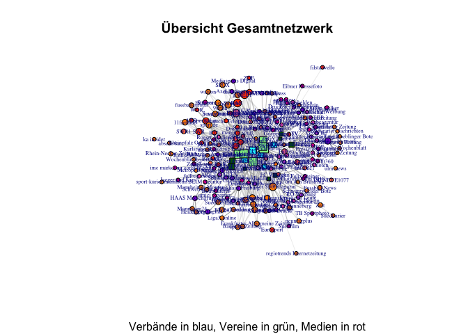

```r
plot(footballmedia,
     asp=1,
     vertex.label.cex=0.5,
     layout=scaled_layout,
     main ="Übersicht Gesamtnetzwerk", sub = "Verbände in blau, Vereine in grün, Medien in rot")
```

```r
# Als PNG speichern
png("footballmedia.png", width = 2000, height = 2000, res = 300)
plot(footballmedia,
     asp=1,
     vertex.label.cex=0.5,
     layout=scaled_layout,
     main ="Übersicht Gesamtnetzwerk", sub = "Verbände in blau, Vereine in grün, Medien in rot")
dev.off()
```

Um eine noch übersichtliche Visualisierung zu erhalten, verwende ich noch zusätzlich das Tool “visNetwork”.

```r
# Knoten entsprechend der Typen formen
V(footballmedia)[V(footballmedia)$type == "medium"]$shape <- "dot"
V(footballmedia)[V(footballmedia)$type == "verein"]$shape <- "square"
V(footballmedia)[V(footballmedia)$type == "verband"]$shape <- "triangle"

# Dicke der Kanten anpassen
E(footballmedia)[E(footballmedia)$weight == "1"]$width <- 5
E(footballmedia)[E(footballmedia)$weight == "2"]$width <- 4
E(footballmedia)[E(footballmedia)$weight == "3"]$width <- 3
E(footballmedia)[E(footballmedia)$weight == "4"]$width <- 2
E(footballmedia)[E(footballmedia)$weight == "5"]$width <- 1

# Größe der Knoten anpassen
## Degree-Werte berechnen
degree_values <- degree(footballmedia)
## Skalierung der Degree-Werte für eine sinnvolle Darstellung
scaled_degree <- 10 + (degree_values - min(degree_values)) / (max(degree_values) - min(degree_values)) * 40
## Größe festlegen
V(footballmedia)[V(footballmedia)$type == "medium"]$size <- scaled_degree[V(footballmedia)$type == "medium"]*2
V(footballmedia)[V(footballmedia)$type == "verein"]$size <- scaled_degree[V(footballmedia)$type == "verein"]
V(footballmedia)[V(footballmedia)$type == "verband"]$size <- scaled_degree[V(footballmedia)$type == "verband"]*2

library(visNetwork)
#visfootballmedia <-
toVisNetworkData(footballmedia) %>%
  c(list(main = "Übersicht Gesamtnetzwerk", sub = "Verbände in blau, Vereine in grün, Medien in rot")) %>%
  do.call(visNetwork, .) %>%
  visPhysics(solver = "forceAtlas2Based",
             forceAtlas2Based = list(minVelocity = 0.75))
```

[interactive chart not shown]

```r
# Als HTML speichern
#library(htmlwidgets)
#visSave(visfootballmedia, file = "footballmedia.html")
```

Das Gesamtnetzwerk bietet eine umfassende Übersicht über die kommunikativen Beziehungen zwischen Profivereinen (hellgrün), Amateurvereinen (dunkelgrün), Verbänden (blau) und Medien (dargestellt je nach Art des Mediums in verschiedenen Rottönen von orange bis violett) im Profi- und Amateurfußball in Baden-Württemberg. Die Visualisierung verdeutlicht die unterschiedlichen Rollen und die Vernetzungsintensität der Akteure in beiden Fußballbereichen.

Die Vereine verteilen sich relativ gleichmäßig im Netzwerk. Während einige Profivereine, wie der VfB Stuttgart, im Zentrum des Netzwerks liegen und stark mit den Medien sowie den Verbänden verknüpft sind, zeigen sich Amateurvereine wie die Stuttgarter Kickers in einer eher peripheren Position. Dies spiegelt die geringere Reichweite und die eingeschränkten Ressourcen der Amateurvereine wider, die ihre Medienarbeit stärker auf lokale Akteure beschränken müssen.

Die wichtigsten Medien im Zentrum sind überregionale Akteure wie transfermarkt.de, kicker Sportmagazin, RAN, WELT, BILD, Sport1, onefootball, Sueddeutsche Zeitung und fussballdaten. Auffällig ist zudem die im sportlichen Bereich relativ breite Berichterstattung einiger Regionalzeitungen wie der Heilbronner Stimme und der Blätter des Zeitungsverlags Waiblingen. Aber auch TV-Dienstleister wie Sportschau, SWR, das aktuelle Sportstudio, DAZN und Sky Deutschland sind hervorzuheben.

## 3.3 Analyse der Teilnetzwerke

Da das Gesamtnetzwerk mit 199 Knoten und 472 Beziehungen sehr umfangreich ist, erstelle ich verschiedene Teilnetzwerke, um das Netzwerk in seinen Einzelteilen besser analysieren zu können. Diese sind in Abhängigkeit von verschiedenen Edge- und Node-Attributen erstellt.

### 3.3.1 Teilnetzwerke nach Vereinskategorie Profis vs. Amateure (Edge-Attribut)

Im Folgenden sollen die verschiedenen Teilnetzwerke nach Vereinskategorie betrachtet und deren Zusammenhang mit bestimmten Zusammenarbeitsmustern untersucht werden.

Die Vereinskategorie habe ich wie folgt kategorisiert: “pro” für Erst- und Zweitligisten, “ama” für Dritt- und Viertligisten

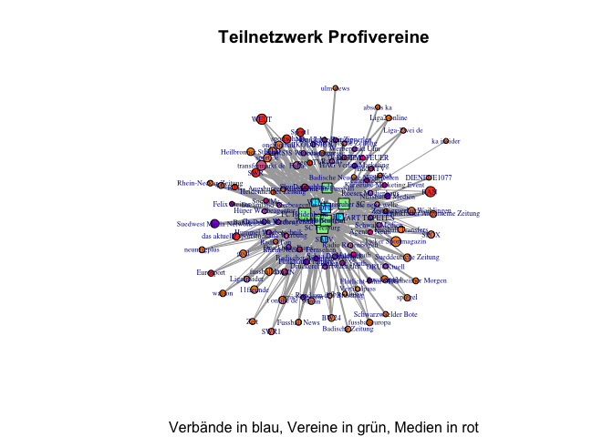

```r
# Knoten entsprechend der Typen formen
V(footballmedia)[V(footballmedia)$type == "medium"]$shape <- "circle"
V(footballmedia)[V(footballmedia)$type == "verein"]$shape <- "square"
V(footballmedia)[V(footballmedia)$type == "verband"]$shape <- "square"

# Größe der Knoten anpassen
## Degree-Werte berechnen
degree_values <- degree(footballmedia)
## Skalierung der Degree-Werte für eine sinnvolle Darstellung
scaled_degree <- 10 + (degree_values - min(degree_values)) / (max(degree_values) - min(degree_values)) * 40
## Größe festlegen
V(footballmedia)[V(footballmedia)$type == "medium"]$size <- scaled_degree[V(footballmedia)$type == "medium"]*0.4
V(footballmedia)[V(footballmedia)$type == "verein"]$size <- scaled_degree[V(footballmedia)$type == "verein"]*0.2
V(footballmedia)[V(footballmedia)$type == "verband"]$size <- scaled_degree[V(footballmedia)$type == "verband"]*0.4

library(igraph)
# Teilnetzwerk pro erstellen: Alle Erst- und Zweitligisten
pro <- subgraph.edges(footballmedia, E(footballmedia)[category=="pro"])
# Visualisierung mit igraph
plot(pro,
     asp=1,
     vertex.label.cex=0.5,
     layout=layout_with_kk,
     main ="Teilnetzwerk Profivereine", sub = "Verbände in blau, Vereine in grün, Medien in rot")
```

```r
# Als PNG speichern
png("pro.png", width = 2000, height = 2000, res = 300)
plot(pro,
     asp=1,
     vertex.label.cex=0.5,
     layout=layout_with_kk,
     main ="Teilnetzwerk Profivereine", sub = "Verbände in blau, Vereine in grün, Medien in rot")
dev.off()
```

Die Profivereine, wie der VfB Stuttgart oder der Karlsruher SC, befinden sich ebenfalls in zentraler Position, eng vernetzt mit den Medien und den Verbänden. Diese zentrale Lage im Netzwerk zeigt, dass sie eine wichtige Rolle in der Kommunikation zwischen den verschiedenen Akteuren spielen. Die enge Anbindung an die Verbände ermöglicht den Vereinen Zugang zu wichtigen Ressourcen und strategischer Unterstützung, was ihre mediale Präsenz weiter stärkt.

Das Netzwerk zeigt eine große Anzahl an Verbindungen zwischen Profivereinen und Medien. Medienakteure wie überregionale Tageszeitungen, Sportmagazine und Online-Plattformen stehen in regem Austausch mit den Vereinen. Besonders auffällig ist die starke Präsenz von überregionalen Medien wie Sky Deutschland, kicker oder RAN, die sich zentral im Netzwerk positionieren. Dies deutet darauf hin, dass die Medienarbeit im Profifußball durch eine strategische Zusammenarbeit mit etablierten und reichweitenstarken Medienakteuren geprägt ist.

Die Vielzahl der Verbindungen zeigt, dass die PR-Arbeit im Profifußball auf klar strukturierte und professionelle Kommunikationskanäle setzt. Die Vereine nutzen diese Kanäle, um gezielt Botschaften zu verbreiten und ein breites Publikum zu erreichen. Hierbei spielen spezialisierte PR-Teams und etablierte Kommunikationsstrategien eine zentrale Rolle, wie in meiner Arbeitshypothese vermutet.

Die Medienpräsenz im Profifußball ist durch eine starke Überregionalität geprägt. Medienakteure mit großer Reichweite haben zahlreiche Verbindungen zu den Vereinen, was deren Bedeutung für die Berichterstattung im Profifußball verdeutlicht. Gleichzeitig sind auch regionale Medien wie die Heilbronner Stimme oder der Schwarzwälder Bote stark vertreten, die auf eine lokale Zielgruppe ausgerichtet sind. Dies zeigt, dass die Medienarbeit im Profibereich sowohl auf überregionale als auch auf regionale Berichterstattung ausgerichtet ist, um eine möglichst breite Aufmerksamkeit zu erzielen.

Innerhalb des Netzwerks lassen sich Unterschiede zwischen den Vereinen erkennen. Profivereine mit größerer Reichweite, wie der VfB Stuttgart, zeigen eine stärkere Vernetzung mit überregionalen Medien und Verbänden. Kleinere Profivereine wie der Karlsruher SC oder der SSV Ulm 1846 scheinen stärker regional orientiert zu sein, weisen jedoch ebenfalls zahlreiche Verbindungen auf. Dies unterstreicht, dass die Größe und Bedeutung eines Vereins die Intensität und Reichweite seiner Kommunikationsbeziehungen beeinflusst.

Das Teilnetzwerk der Profivereine bestätigt meine Hypothese, dass die Medien- und PR-Arbeit im Profifußball durch eine hohe Zentralität, strategische Kontrolle und professionelle Ressourcen geprägt ist. Die enge Vernetzung zwischen Vereinen, Verbänden und überregionalen Medien zeigt, wie stark institutionalisierte Strukturen und gezielte Kommunikationsstrategien die mediale Präsenz der Profivereine beeinflussen. Die Ergebnisse verdeutlichen die Bedeutung professioneller Netzwerke für den Erfolg der Medienarbeit im Profibereich und liefern wertvolle Erkenntnisse für die Analyse der Unterschiede zum Amateurfußball.

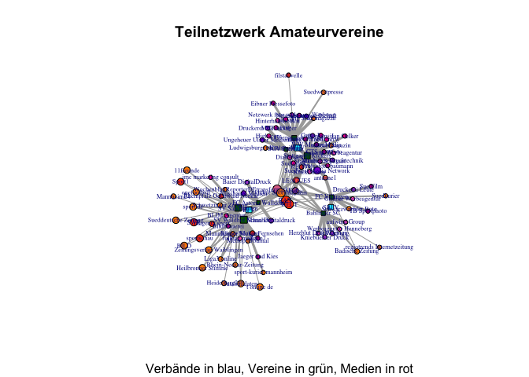

```r
library(igraph)
# Teilnetzwerk ama erstellen: Alle Dritt- und Viertligisten
ama <- subgraph.edges(footballmedia, E(footballmedia)[category=="ama"])

# Visualisierung mit igraph
plot(ama,
     asp=1,
     vertex.label.cex=0.5,
     layout=layout_with_kk,
     main ="Teilnetzwerk Amateurvereine", sub = "Verbände in blau, Vereine in grün, Medien in rot")
```

```r
# Als PNG speichern
png("ama.png", width = 2000, height = 2000, res = 300)
plot(ama,
     asp=1,
     vertex.label.cex=0.5,
     layout=layout_with_kk,
     main ="Teilnetzwerk Amateurvereine", sub = "Verbände in blau, Vereine in grün, Medien in rot")
dev.off()
```

Im Vergleich zum Profibereich wirkt das Netzwerk der Amateurvereine deutlich weniger dicht und zentralisiert. Es zeigt eine fragmentierte Struktur, in der Vereine, Medien und Verbände teilweise isoliert voneinander agieren. Die zentrale Position der Verbände wie etwa des WFV ist zwar sichtbar, jedoch weniger dominant als im Profibereich. Dies deutet darauf hin, dass die koordinierende Rolle der Verbände im Amateurfußball weniger stark ausgeprägt ist.

Viele Verbindungen im Netzwerk sind auf einzelne Cluster beschränkt. Dies deutet darauf hin, dass Amateurvereine ihre Medienarbeit stark regional ausrichten und in erster Linie mit lokalen Partnern zusammenarbeiten. Diese Fragmentierung spiegelt die geringere institutionelle Einbettung und die flexibleren Strukturen im Amateurfußball wider.

Die Verbindungen zwischen Amateurvereinen und Medien sind deutlich begrenzter als im Profibereich. Medienakteure im Amateurnetzwerk sind überwiegend lokale und regionale Zeitungen wie die Heilbronner Stimme, die Ludwigsburger Kreiszeitung oder die Badische Zeitung, Nachrichtenportale oder spezialisierte kleinere Plattformen. Beispiele hierfür sind die Streamingplattform LEAGUES, die die Spiele der Regionalliga zeigt, sowie das Statistikportal FuPa. Diese enge Fokussierung auf regionale Medien zeigt, dass Amateurvereine auf eine lokal begrenzte Berichterstattung angewiesen sind.

Auch die Anzahl der Verbindungen pro Verein ist geringer als im Profibereich. Dies deutet darauf hin, dass die Ressourcen und Kapazitäten der Amateurvereine, um eine breit angelegte Medienarbeit zu leisten, eingeschränkt sind. Die Zusammenarbeit zwischen PR und Journalismus scheint im Amateurfußball stärker durch persönliche Netzwerke und direkte Kontakte geprägt zu sein, wie es in der Hypothese formuliert wurde.

Im Amateurbereich spielen regionale und lokale Medien eine dominante Rolle. Überregionale Medien oder große Plattformen, die im Profibereich stark vertreten sind, sind nur noch vereinzelt zu finden. Dies spiegelt die geringere öffentliche und mediale Reichweite von Amateurvereinen wider. Die Medienpräsenz ist stark ortsgebunden, was darauf hinweist, dass Amateurvereine weniger strategische Kontrolle über ihre Außendarstellung haben und auf die Berichterstattung der lokalen Presse angewiesen sind.

Innerhalb des Netzwerks lassen sich Unterschiede zwischen den Amateurvereinen erkennen. Einige Vereine wie die Stuttgarter Kickers weisen vergleichsweise viele Verbindungen zu Medien und Verbänden auf, was auf eine aktivere Medienarbeit hinweist. Andere Vereine sind eher peripher positioniert und verfügen über wenige Kontakte, was auf eine geringere Kommunikationsaktivität oder begrenzte Ressourcen hindeutet. Dies verdeutlicht die Heterogenität im Amateurfußball sowie die Sonderrolle der Stuttgarter Kickers als ehemaligem Profiverein und zeigt, dass Vereine je nach Größe und Bedeutung unterschiedlich stark in das Kommunikationsnetzwerk eingebunden sind.

Das Teilnetzwerk der Amateurvereine bestätigt meine Hypothese, dass die Kommunikationsstrukturen im Amateurfußball weniger dicht, weniger strategisch und stärker regional geprägt sind. Die geringe Anzahl an Verbindungen und die Fragmentierung des Netzwerks spiegeln die begrenzten Ressourcen und die flexibleren Strukturen im Amateurfußball wider. Die Medienarbeit basiert hier stärker auf persönlichen Beziehungen und direkten Interaktionen, während überregionale Berichterstattung nahezu keine Rolle spielt. Diese Analyse zeigt die deutlichen Unterschiede zum Profibereich und liefert wertvolle Einblicke in die besonderen Herausforderungen und Gegebenheiten der Medienarbeit im Amateurfußball.

## 3.4 Netzwerkmaße

Im Folgenden sollen verschiedene Netzwerkmaße untersucht werden. Dazu gehören Komponenten, Dyaden, Triaden und Ego-Netzwerke.

### 3.4.1 Komponenten

```r
# Anzahl der Komponenten
count_components(footballmedia)
```

```
## [1] 1
```

Das Netzwerk besteht aus einer einzigen **Komponente**, was bedeutet, dass alle Knoten in irgendeiner Form miteinander verbunden sind. Eine weitergehende Analyse hinsichtlich starker und schwacher Komponenten erübrigt sich daher, da keine zusätzlichen Unterstrukturen im Netzwerk existieren.

### 3.4.2 Dyaden

```r
# Durchführung des Dyadenzensus
dyad_census(footballmedia)
```

```
## $mut
## [1] 472
##
## $asym
## [1] 0
##
## $null
## [1] 19229
```

```r
# Ausgabe der dyadischen Beziehungen nach dem MAN-Schema
# M = Mutal (reziprok)
# A = Asymmetrical (einseitig gerichtet)
# N = Null (keine Beziehung)
```

**Dyaden** stellen wesentliche Bausteine für Netzwerke dar. Da das untersuchte Netzwerk jedoch ungerichtet ist, ergibt sich zwangsläufig ein Asymmetrie-Wert von 0. Alle 472 Beziehungen im Netzwerk sind reziprok, während 19.229 potenzielle Beziehungen nicht existieren. Eine weiterführende Analyse der reziproken Beziehungen würde somit keine zusätzlichen Erkenntnisse liefern, da sie die Eigenschaften des Gesamtnetzwerks vollständig widerspiegelt.

### 3.4.3 Triaden

Der Triadenzensus ist ein etabliertes Instrument, um die Zusammensetzung von Netzwerken zu analysieren und zu vergleichen.

```r
# Der Zensus folgt dem abgewandelten M-A-N Schema in der Beschreibung und liefert die Ergebnisse von 16 Triadentypen.
# Die Reihenfolge der Ausgabe lässt sich über den Befehl ?triad_census festlegen.
?triad_census
# Hier werden 16 Triadentypen numerisch aufsteigend abgetragen.

# Übersicht über Triaden in einem Netzwerk
triad_census(footballmedia)
```

```
##  [1] 1209664       0   75109       0       0       0       0       0       0
## [10]       0    8903       0       0       0       0      23
```

Im Zusammenhang mit dem **Triadenzensus** zeigt sich ebenfalls eine typische Struktur für ein ungerichtetes Netzwerk. Werte werden ausschließlich für reziproke Triadentypen ausgegeben: Das Netzwerk umfasst 1.209.664 Triaden ohne Verbindungen, 75.109 Triaden mit einer Verbindung, 8.903 Triaden mit zwei Verbindungen und 23 vollständig verbundene Triaden.

```r
# Mit dem Befehl motifs lassen sich spezifische Triadentypen anzeigen:
# Das numerische Argument legt fest, wie viele Verbindungen untersucht werden sollen.

motifs(footballmedia, size=3)
```

```
## [1]   NA   NA 8903   23
```

```r
count_motifs(footballmedia, size=3)
```

```
## [1] 8926
```

```r
# Die Anzahl der unterschiedlichen motifs entspricht grob dem Triadenzensus.
# Der Gesamtwert gibt alle triadischen Verbindungen in einem Netzwerk an.
```

Insgesamt existieren 8.926 triadische Beziehungen im Netzwerk. Diese Zahlen verdeutlichen die hierarchische Struktur und Verknüpfungstiefe des Netzwerks.

### 3.4.4 Ego-Netzwerke

Manchmal ist es hilfreich, spezifische Knoten aus dem Netzwerk zu isolieren und genauer zu untersuchen. Dieser Ansatz ermöglicht es, einzelne Akteure und deren direkte sowie indirekte Beziehungen besser zu verstehen. Mit diesem Verfahren „zoomt“ man auf einen bestimmten Knoten im Netzwerk, um detaillierte Analysen durchzuführen. Jedes Netzwerk besteht dabei aus einem Ego (dem betrachteten Knoten) und seinen Alteri (den direkt oder indirekt verbundenen Knoten). Diese sogenannten **Ego-Netzwerke** lassen sich einzeln analysieren, was tiefere Einblicke in die Position und Bedeutung des betrachteten Knotens liefert.

Da es für die Deutung des Netzwerks von großer Bedeutung sein kann, wer im Netzwerk die meisten Beziehungen hat, und welche Struktur dessen direktes Netzwerk aufweist, wurde der 1. FC Heidenheim als Knoten mit dem höchsten Degree-Wert ausgewählt. Anschließend wurden die Ego-Netzwerke des Vereins erstellt, um die verschiedenen Beziehungsgrade zu analysieren.

**Ego-Netzwerk erster Ordnung**

```r
library(igraph)
library(visNetwork)

# Knoten mit den meisten Verbindungen anzeigen
ego_size(footballmedia)
```

```
##   [1]  2  2  2  2  2  2  2  2  2  2  2  2  2  2  2  2  3  2  2  2  2  2  2  2  2
##  [26]  2  2  2  2  2  2  2  2  2  3  2  2  2  2  2  2  2  2  2  2  2  2  2  2  2
##  [51]  2  3  2  3  2  2  2  2  2  2  6  2  6  7  2  2  3  2  5  2  5 16  3  3  3
##  [76]  4  3  3  8 10 11  8 11  3  2 16  2  3  2  4  2  5  5  3  2  4 11  3  8  2
## [101] 15  2  2  2  2  2  2  2  2  2  2  2  2  2  2  2  2  2  2  7  2  2 10  2  7
## [126]  5  2  9  2  7  2  9  6  5  8  4  2  2  2  2 15  5  3  4  4  3  5  4  2  2
## [151]  5  2  9  2  2  2  4  2  4  6 10  2  8  9  2  2  2  2  7  3  3  9  9  7  2
## [176]  5  6  2  5  9  7 15 10 14 11 53 16 18 46  5 47 12 26 28 31 46 41 46  8
```

```r
which.max(ego_size(footballmedia))
```

```
## [1] 186
```

```r
# Berechnung des Degree-Werts und Selektierung des Knotens mit dem höchsten Degree-Wert
degree(footballmedia)
```

```
##          Rund um den Brustring                   Vertikalpass
##                              1                              1
##                   vfb exklusiv                    ART TAPETEN
##                              1                              1
##             Baier DigitalDruck            Bairle Druck Medien
##                              1                              1
##                     DRUCKtuell                Druckhaus Frank
##                              1                              1
##         Druckerei Furtwaengler                       Grom Ilg
##                              1                              1
##            Hummel Werbetechnik              Kniebuehler Druck
##                              1                              1
##                Druckerei Leute         Manhillen Drucktechnik
##                              1                              1
##            Druckerei Memminger                     RO Werbung
##                              1                              1
##             Schaa Digitaldruck                 Schwall Medien
##                              2                              1
##                 Werbepunkt Ulm         Druck Medien Zipperlen
##                              1                              1
##                     baden film             Pressefoto baumann
##                              1                              1
##                   Bildbrauerei                  CTS sportfoto
##                              1                              1
##              Eibner Pressefoto                     entermedia
##                              1                              1
##             Flutlicht-Film OHG                Jaeger und Kies
##                              1                              1
##                 WW ModernMedia                   raumSicht360
##                              1                              1
##                       Suedfilm                  Felix Steiner
##                              1                              1
##                  TB Sportphoto                          Zone7
##                              1                              1
##                Electronic Arts                   Agentur Neun
##                              2                              1
##                  amici Agentur                   BLIM Agentur
##                              1                              1
##                      Convensis                   DIGITALFEUER
##                              1                              1
```

[output cut: 145 more lines]

```
##                             10                             52
##                   FC Villingen                  Goeppinger SV
##                             15                             17
##                  Karlsruher SC                           SBFV
##                             45                              4
##                    SC Freiburg                   SGV Freiberg
##                             46                             11
##            Stuttgarter Kickers                  SV Sandhausen
##                             25                             27
##            SV Waldhof Mannheim                 TSG Hoffenheim
##                             30                             45
##               SSV Ulm Fussball                  VfB Stuttgart
##                             40                             45
##                            WFV
##                              7
```

```r
which.max(degree(footballmedia))
```

```
## FC Heidenheim
##           186
```

```r
# Selektierung aller Knoten, die mit "FC Heidenheim" verbunden sind
b_king <- make_ego_graph(footballmedia, order = 1, nodes = V(footballmedia)$name == "FC Heidenheim", mode ="all")

# Zwischenschritt zur Herstellung des igraph-Objekts b_king1
b_king1 <- b_king[[1]]
b_king1
```

```
## IGRAPH 6087992 UNWB 53 57 --
## + attr: name (v/c), type (v/c), liga (v/c), rechtsform (v/c), verband
## | (v/c), media (v/c), reichweite (v/c), shape (v/c), color (v/c), size
## | (v/n), weight (e/c), liga (e/c), category (e/c), width (e/n), label
## | (e/l)
## + edges from 6087992 (vertex names):
##  [1] SWR1               --SWR           RTL                --sport de
##  [3] DAZN               --DFL           Sky Deutschland    --DFL
##  [5] Sport1             --DFL           Bairle Druck Medien--FC Heidenheim
##  [7] Druckhaus Frank    --FC Heidenheim Hummel Werbetechnik--FC Heidenheim
##  [9] Felix Steiner      --FC Heidenheim SocialMe           --FC Heidenheim
## + ... omitted several edges
```

[figure not shown]

```r
# Anpassung der Farbe der Knoten und Kanten
V(b_king1)$color <- "gold"
E(b_king1)$color <- "grey80"

# Visualisierung mit igraph
plot(b_king1,
     asp=1,
     vertex.label.cex=0.5,
     layout=layout_with_kk,
     main ="Ego-Netzwerk 1.FC Heidenheim, erster Grad", sub = "nur direkte Beziehungen des ersten Grads (52 alteri)")
```

```r
# Als PNG speichern
png("b_king1.png", width = 2000, height = 2000, res = 300)
plot(b_king1,
     asp=1,
     vertex.label.cex=0.5,
     layout=layout_with_kk,
     main ="Ego-Netzwerk 1.FC Heidenheim, erster Grad", sub = "nur direkte Beziehungen des ersten Grads (52 alteri)")
dev.off()
```

Dieses Netzwerk umfasst ausschließlich die direkten Verbindungen des 1. FC Heidenheim. Es zeigt, dass der Verein insgesamt 52 Medien und Verbände als direkte Partner hat. Diese Beziehungen umfassen offizielle Kommunikationspartner und weitere Akteure, die eine Rolle in der Berichterstattung über den Verein spielen.